# Trabajo 2 Teoría de la Decisión

Belén Puerta González

2024-11-11

# *Elección de una estrategia de marketing digital para una empresa*

Una empresa de tecnología, **Tech Solutions**, desea elegir la mejor estrategia de marketing digital para el próximo año con el fin de mejorar su visibilidad, atraer más clientes y aumentar sus ventas. Para ello, ha identificado cinco alternativas de estrategias de marketing digital, cada una con características y costos distintos. Para decidir cuál es la mejor opción, se evaluarán los criterios que se consideran clave para el éxito de la campaña. Estos criterios son:

1. **Alcance del público objetivo (puntuación sobre 100)**: Representa la capacidad de la estrategia para llegar a un gran número de personas en el mercado objetivo.
2. **Costo (miles de euros)**: Se refiere al costo estimado de implementación de la estrategia durante el año.
3. **Retorno de inversión (ROI, en porcentaje)**: Calcula la ganancia potencial en comparación con el costo de la estrategia.
4. **Duración de la estrategia (meses)**: Tiempo durante el cual la estrategia tiene efecto y se espera que mantenga su impacto.
5. **Capacidad de segmentación (puntuación sobre 100)**: Evalúa qué tan bien la estrategia puede personalizarse o dirigirse a nichos específicos.
6. **Flexibilidad de ajustes (puntuación de 1 a 10)**: La capacidad de la estrategia para adaptarse a cambios en el mercado. Una puntuación más alta indica una mayor facilidad para realizar ajustes rápidos en la estrategia si es necesario.

Se presentan cinco alternativas de estrategias de marketing digital que la empresa podría adoptar, junto con los datos relevantes para cada una de ellas:

##### **A1: Publicidad en Redes Sociales**

- **Alcance del público objetivo**: 85 puntos
- **Costo**: 30 mil euros
- **Retorno de inversión (ROI)**: 150%
- **Duración de la estrategia**: 12 meses
- **Capacidad de segmentación**: 90 puntos
- **Flexibilidad de ajustes**: 9

##### **A2: Marketing de Contenidos**

- **Alcance del público objetivo**: 70 puntos
- **Costo**: 20 mil euros
- **Retorno de inversión (ROI)**: 120%
- **Duración de la estrategia**: 18 meses
- **Capacidad de segmentación**: 80 puntos
- **Flexibilidad de ajustes**: 6

##### **A3: Email Marketing**

- **Alcance del público objetivo**: 60 puntos
- **Costo**: 10 mil euros
- **Retorno de inversión (ROI)**: 200%
- **Duración de la estrategia**: 6 meses
- **Capacidad de segmentación**: 85 puntos
- **Flexibilidad de ajustes**: 8

##### **A4: Publicidad en Buscadores (SEM)**

- **Alcance del público objetivo**: 75 puntos
- **Costo**: 25 mil euros
- **Retorno de inversión (ROI)**: 140%
- **Duración de la estrategia**: 9 meses
- **Capacidad de segmentación**: 88 puntos
- **Flexibilidad de ajustes**: 9

##### **A5: Colaboraciones con Influencers**

- **Alcance del público objetivo**: 90 puntos
- **Costo**: 35 mil euros
- **Retorno de inversión (ROI)**: 130%
- **Duración de la estrategia**: 6 meses
- **Capacidad de segmentación**: 75 puntos
- **Flexibilidad de ajustes**: 6

#### Pesos de los Criterios

La empresa ha definido los pesos para cada criterio, considerando su importancia para el éxito de la estrategia de marketing:

- **Alcance del público objetivo: 3** → Es importante que la estrategia tenga un alcance amplio para maximizar la visibilidad.
- **Costo: 2** → Se debe considerar el presupuesto disponible.
- **Retorno de inversión (ROI): 3.5** → Este es uno de los criterios más importantes, ya que representa la ganancia potencial de la estrategia.
- **Duración de la estrategia: 1** → La duración es menos importante, pues se espera que cualquier estrategia tenga impacto en el corto o mediano plazo.
- **Capacidad de segmentación: 2.5** → Es fundamental que la estrategia se dirija adecuadamente al público objetivo.
- **Flexibilidad de ajustes: 2** → La capacidad de realizar cambios es importante para adaptarse a posibles cambios de mercado.

Utilizando técnicas de análisis multicriterio como **AHP**, **ELECTRE**, y **PROMETHEE**, determina cuál de las estrategias de marketing digital es la mejor opción para *Tech Solutions* en base a los criterios y pesos mencionados.

## 1. MÉTODO PROMETHEE

Analizando el enunciado, obtendríamos la siguiente tabla:

```r
library(knitr)

# Definición de los criterios
criterios <- c("Alcance del público objetivo", "Costo", "Retorno de inversión (ROI)", "Duración de la estrategia", "Capacidad de segmentación", "Flexibilidad de ajustes")

# Definición de los valores Min/Max para cada criterio
min_max <- c("Max", "Min", "Max", "Max", "Max", "Max")

# Alternativas
alternativas <- c("A1", "A2", "A3", "A4", "A5")

# Definición de los valores para cada alternativa
A1 <- c(85, 30, 150, 12, 90, 9)  # Publicidad en Redes Sociales
A2 <- c(70, 20, 120, 18, 80, 6)  # Marketing de Contenidos
A3 <- c(60, 10, 200, 6, 85, 8)   # Email Marketing
A4 <- c(75, 25, 140, 9, 88, 9)   # Publicidad en Buscadores (SEM)
A5 <- c(90, 35, 130, 6, 75, 6)   # Colaboraciones con Influencers

# Pesos de los criterios, antes de aplicar el método Promethee los normalizamos ya que para dicho método es necesario que sumen 1.
p <- c(3, 2, 3.5, 1, 2.5, 2)

# Valores de Min/Max (0 o 1) dependiendo si el valor debe ser minimizado o maximizado
q <- c(1, 0, 1, 1, 1, 1)

# Valores de los umbrales (valores arbitrarios para cada criterio de referencia)
s <- c(90, 40, 220, 20, 100, 10)

# Crear la tabla con los datos
tabla <- data.frame("Criterios" = criterios, "Min/Max" = min_max, A1, A2, A3, A4, A5, p, q, s)

# Mostrar la tabla
kable(tabla, caption = "Tabla de Evaluación de Estrategias de Marketing Digital")
```

Tabla de Evaluación de Estrategias de Marketing Digital

| Criterios | Min.Max | A1 | A2 | A3 | A4 | A5 | p | q | s |
| --- | --- | --- | --- | --- | --- | --- | --- | --- | --- |
| Alcance del público objetivo | Max | 85 | 70 | 60 | 75 | 90 | 3.0 | 1 | 90 |
| Costo | Min | 30 | 20 | 10 | 25 | 35 | 2.0 | 0 | 40 |
| Retorno de inversión (ROI) | Max | 150 | 120 | 200 | 140 | 130 | 3.5 | 1 | 220 |
| Duración de la estrategia | Max | 12 | 18 | 6 | 9 | 6 | 1.0 | 1 | 20 |
| Capacidad de segmentación | Max | 90 | 80 | 85 | 88 | 75 | 2.5 | 1 | 100 |
| Flexibilidad de ajustes | Max | 9 | 6 | 8 | 9 | 6 | 2.0 | 1 | 10 |

#### Matriz de decisión

```r
datos = multicriterio.crea.matrizdecision(c(85, -30, 150, 12, 90, 9,
                                            70, -20, 120, 18, 80, 6,
                                            60, -10, 200, 6, 85, 8,
                                            75, -25, 140, 9, 88, 9,
                                            90, -35, 130, 6, 75, 6),
                                          numalternativas = 5, numcriterios = 6,
                                          v.nombresalt = alternativas,
                                          v.nombrescri = criterios)
datos
```

```
##    Alcance del público objetivo Costo Retorno de inversión (ROI)
## A1                           85   -30                        150
## A2                           70   -20                        120
## A3                           60   -10                        200
## A4                           75   -25                        140
## A5                           90   -35                        130
##    Duración de la estrategia Capacidad de segmentación Flexibilidad de ajustes
## A1                        12                        90                       9
## A2                        18                        80                       6
## A3                         6                        85                       8
## A4                         9                        88                       9
## A5                         6                        75                       6
```

Antes de definir la tabla de preferencias veamos el número de función que le corresponde a cada cada criterio según su nivel de importancia:

*Alcance del público objetivo (peso = 3): Este criterio se maximiza y busca gran visibilidad, por lo que una Función tipo III podría ser adecuada, ya que permite que la preferencia crezca linealmente conforme aumente el alcance.

*Costo (peso = 2): Aquí se busca minimizar el gasto. La Función tipo IV sería apropiada, dado que permite identificar diferencias pequeñas, medianas y grandes en costos, útil para presupuestos ajustados.

*Retorno de inversión (ROI) (peso = 3.5): Este es un criterio fundamental en el que se busca maximizar. La Función tipo III es adecuada porque permite que la preferencia aumente conforme suba el ROI, reflejando la importancia de diferencias graduales en el retorno.

*Duración de la estrategia (peso = 1): Es un criterio menos importante y podría usarse una Función tipo I, considerando solo si una estrategia dura más o menos tiempo.

*Capacidad de segmentación (peso = 2.5): Aquí también se busca maximizar, y la Función tipo III sería útil, ya que permite un incremento gradual en la preferencia conforme la capacidad de segmentación mejora, capturando pequeñas diferencias en la personalización de la estrategia.

*Flexibilidad de ajustes (peso = 2): La Función tipo V podría ser la opción ideal, ya que permite indiferencia en los niveles bajos de flexibilidad pero da preferencia a mayores niveles, reflejando la utilidad de adaptarse rápidamente a cambios en el mercado.

```r
# La tabla de preferencias la rellenamos de la siguiente manera:
# num.funcion, qi, pi, si
tablaf_pref <- matrix(c(3,1,3,90,
                        4,0,2,40,
                        3,1,3.5,220,
                        1,1,1,20,
                        3,1,2.5,100,
                        5,1,2,10), ncol = 4, byrow = T)
colnames(tablaf_pref) <- c("num.pref","qi","pi","si")
tablaf_pref
```

```
##      num.pref qi  pi  si
## [1,]        3  1 3.0  90
## [2,]        4  0 2.0  40
## [3,]        3  1 3.5 220
## [4,]        1  1 1.0  20
## [5,]        3  1 2.5 100
## [6,]        5  1 2.0  10
```

### 1.1. MÉTODO PROMETHEE I

```r
# Aplicamos método
tab.Pthee.i <- multicriterio.metodo.promethee_i(datos, pesos.criterios = tablaf_pref[,3]/sum(tablaf_pref[,3]),
tab.fpref = tablaf_pref)
tab.Pthee.i
```

```
## $tabla.indices
##           A1        A2        A3        A4        A5
## A1 0.0000000 0.7857143 0.4642857 0.6785714 0.7857143
## A2 0.2142857 0.0000000 0.2857143 0.2142857 0.3928571
## A3 0.3928571 0.7142857 0.0000000 0.3928571 0.7142857
## A4 0.1428571 0.7857143 0.4642857 0.0000000 0.7857143
## A5 0.2142857 0.4642857 0.2142857 0.2142857 0.0000000
##
## $vflujos.ent
##       A1       A2       A3       A4       A5
## 2.714286 1.107143 2.214286 2.178571 1.107143
##
## $vflujos.sal
##        A1        A2        A3        A4        A5
## 0.9642857 2.7500000 1.4285714 1.5000000 2.6785714
##
## $tablarelacionsupera
##     A1  A2  A3  A4  A5
## A1 0.5 1.0 1.0 1.0 1.0
## A2 0.0 0.5 0.0 0.0 0.0
## A3 0.0 1.0 0.5 1.0 1.0
## A4 0.0 1.0 0.0 0.5 1.0
## A5 0.0 1.0 0.0 0.0 0.5
```

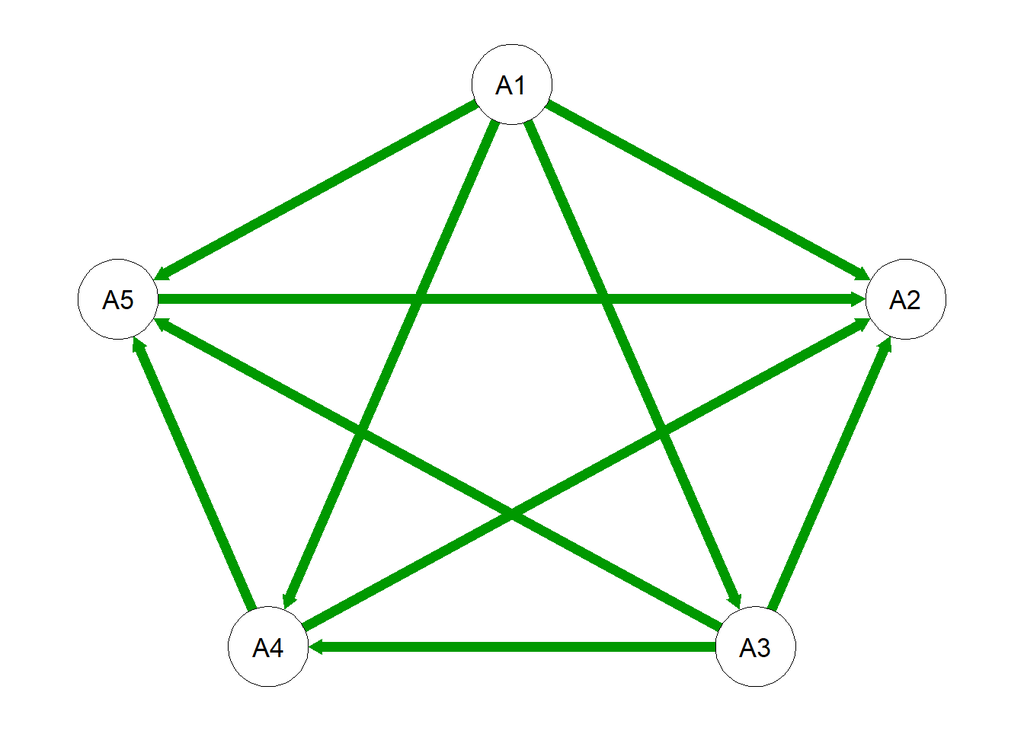

```r
# Grafo:
qgraph::qgraph(tab.Pthee.i$tablarelacionsupera)
```

**CONCLUSIÓN**:Para el método Promethee I, la alternativa A1 (Publicidad en Redes Sociales) supera al resto de alternativas directamente. A2 no supera a ninguna otra alternativa, A3 supera a A2, a A4 y a A5, A4 supera a A2 y a A5, y A5 supera a A2.

#### Método promethee I (medias)

```r
# Aplicamos método
tab.Pthee.i_med <- multicriterio.metodo.promethee_i_med(datos, pesos.criterios = tablaf_pref[,3]/sum(tablaf_pref[,3]),
tab.fpref = tablaf_pref)
tab.Pthee.i_med
```

```
## $tabla.indices
##           A1        A2        A3        A4        A5
## A1 0.0000000 0.7857143 0.4642857 0.6785714 0.7857143
## A2 0.2142857 0.0000000 0.2857143 0.2142857 0.3928571
## A3 0.3928571 0.7142857 0.0000000 0.3928571 0.7142857
## A4 0.1428571 0.7857143 0.4642857 0.0000000 0.7857143
## A5 0.2142857 0.4642857 0.2142857 0.2142857 0.0000000
##
## $vflujos.ent
##        A1        A2        A3        A4        A5
## 0.6785714 0.2767857 0.5535714 0.5446429 0.2767857
##
## $vflujos.sal
##        A1        A2        A3        A4        A5
## 0.2410714 0.6875000 0.3571429 0.3750000 0.6696429
##
## $tablarelacionsupera
##    A1 A2 A3 A4 A5
## A1  0  1  1  1  1
## A2  0  0  0  0  0
## A3  0  1  0  1  1
## A4  0  1  0  0  1
## A5  0  1  0  0  0
```

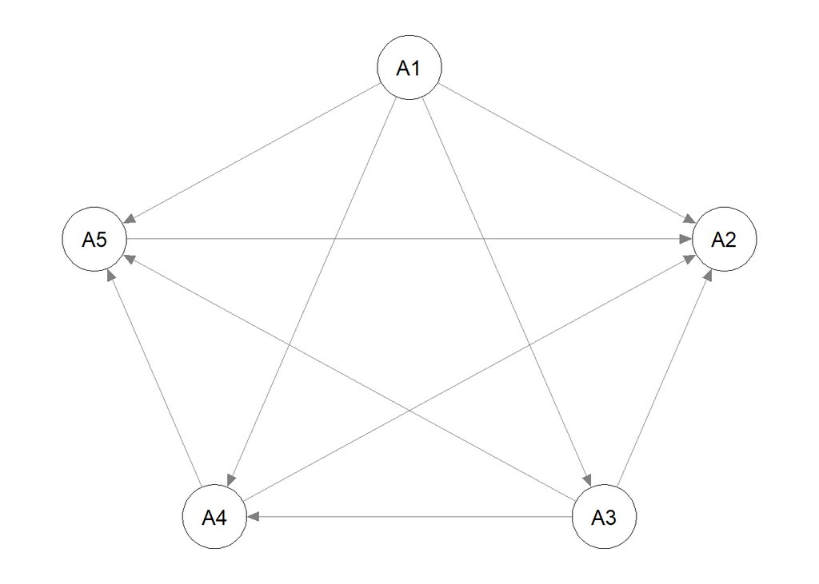

```r
# Grafo:
qgraph::qgraph(tab.Pthee.i_med$tablarelacionsupera)
```

**CONCLUSIÓN**:Para el método Promethee I (medias), la alternativa A1 (Publicidad en Redes Sociales) supera al resto de alternativas directamente. A2 no supera a ninguna otra alternativa, A3 supera a A2, a A4 y a A5, A4 supera a A2 y a A5 ,y A5 supera a A2.

Los resultados obtenidos en el método Promethee I y Promethee I (medias) coinciden.

### 1.2. MÉTODO PROMETHEE II

```r
# Aplicamos método
tab.Pthee.ii <- multicriterio.metodo.promethee_ii(datos, pesos.criterios = tablaf_pref[,3]/sum(tablaf_pref[,3]),
tab.fpref = tablaf_pref)
tab.Pthee.ii
```

```
## $tabla.indices
##           A1        A2        A3        A4        A5
## A1 0.0000000 0.7857143 0.4642857 0.6785714 0.7857143
## A2 0.2142857 0.0000000 0.2857143 0.2142857 0.3928571
## A3 0.3928571 0.7142857 0.0000000 0.3928571 0.7142857
## A4 0.1428571 0.7857143 0.4642857 0.0000000 0.7857143
## A5 0.2142857 0.4642857 0.2142857 0.2142857 0.0000000
##
## $vflujos.netos
##         A1         A2         A3         A4         A5
##  1.7500000 -1.6428571  0.7857143  0.6785714 -1.5714286
##
## $tablarelacionsupera
##     A1  A2  A3  A4  A5
## A1 0.5 1.0 1.0 1.0 1.0
## A2 0.0 0.5 0.0 0.0 0.0
## A3 0.0 1.0 0.5 1.0 1.0
## A4 0.0 1.0 0.0 0.5 1.0
## A5 0.0 1.0 0.0 0.0 0.5
```

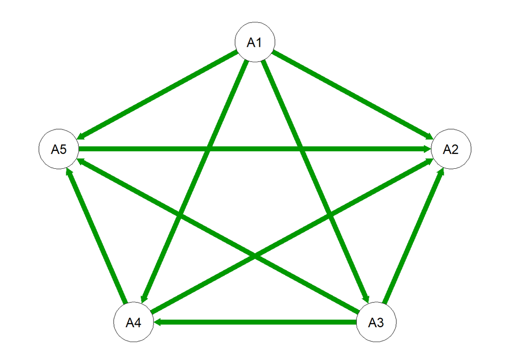

```r
# Grafo:
qgraph::qgraph(tab.Pthee.ii$tablarelacionsupera)
```

```r
# ORDENACIÓN FINAL ALTERNATIVAS DEL MÉTODO PROMETHEE II:
# La ordenación que establecen seria la siguiente:
order(tab.Pthee.ii$vflujos.netos,decreasing = T)
```

```
## [1] 1 3 4 5 2
```

**CONCLUSIÓN**:Para el método Promethee II, la mejor alternativa es A1 (Publicidad en Redes Sociales) ya que tiene el mayor flujo neto con un valor de 2. Además, supera al resto de alternativas directamente. A2 no supera a ninguna otra alternativa, A3 supera a A2, a A4 y a A5, A4 supera a A2 y a A5 ,y A5 supera a A2.

#### Método promethee II (medias)

```r
# Aplicamos método
tab.Pthee.ii_med <- multicriterio.metodo.promethee_ii_med(datos, pesos.criterios = tablaf_pref[,3]/sum(tablaf_pref[,3]),
tab.fpref = tablaf_pref)
tab.Pthee.ii_med
```

```
## $tabla.indices
##           A1        A2        A3        A4        A5
## A1 0.0000000 0.7857143 0.4642857 0.6785714 0.7857143
## A2 0.2142857 0.0000000 0.2857143 0.2142857 0.3928571
## A3 0.3928571 0.7142857 0.0000000 0.3928571 0.7142857
## A4 0.1428571 0.7857143 0.4642857 0.0000000 0.7857143
## A5 0.2142857 0.4642857 0.2142857 0.2142857 0.0000000
##
## $vflujos.netos
##         A1         A2         A3         A4         A5
##  0.4375000 -0.4107143  0.1964286  0.1696429 -0.3928571
##
## $tablarelacionsupera
##    A1 A2 A3 A4 A5
## A1  0  1  1  1  1
## A2  0  0  0  0  0
## A3  0  1  0  1  1
## A4  0  1  0  0  1
## A5  0  1  0  0  0
```

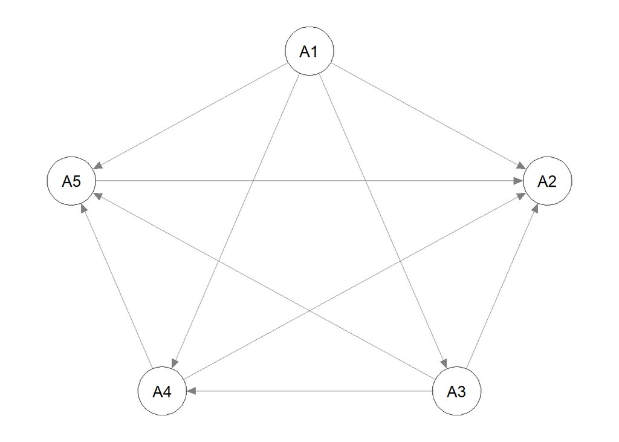

```r
# Grafo:
qgraph::qgraph(tab.Pthee.ii_med$tablarelacionsupera)
```

```r
# ORDENACIÓN FINAL ALTERNATIVAS DEL MÉTODO PROMETHEE II (MEDIAS):
# La ordenación que establecen seria la siguiente:
order(tab.Pthee.ii_med$vflujos.netos,decreasing = T)
```

```
## [1] 1 3 4 5 2
```

Los resultados obtenidos en el método Promethee II y Promethee II (medias) coinciden.

## 2. MÉTODO ELECTRE

Aplicamos el método:

```r
# Retomamos la matriz de decisión y los pesos de los criterios:
datos
```

```
##    Alcance del público objetivo Costo Retorno de inversión (ROI)
## A1                           85   -30                        150
## A2                           70   -20                        120
## A3                           60   -10                        200
## A4                           75   -25                        140
## A5                           90   -35                        130
##    Duración de la estrategia Capacidad de segmentación Flexibilidad de ajustes
## A1                        12                        90                       9
## A2                        18                        80                       6
## A3                         6                        85                       8
## A4                         9                        88                       9
## A5                         6                        75                       6
```

```r
p <- c(3, 2, 3.5, 1, 2.5, 2)

# Umbrales de discordancia (d):
# Para el Costo, usamos un valor más bajo para no permitir grandes diferencias en este criterio.
d <- c(Inf, 60, Inf, Inf, Inf, Inf)  # Para el Costo: 60


electre <- multicriterio.metodoELECTRE_I(datos,
                                      pesos.criterios = p,
                                      nivel.concordancia.minimo.alpha = 0.7,
                                      no.se.compensan = d,
                                      que.alternativas = T)
electre
```

```
## $datos
##                 Alcance del público objetivo Costo Retorno de inversión (ROI)
## A1                                        85   -30                      150.0
## A2                                        70   -20                      120.0
## A3                                        60   -10                      200.0
## A4                                        75   -25                      140.0
## A5                                        90   -35                      130.0
## pesos.criterios                            3     2                        3.5
## no.se.compensan                          Inf    60                        Inf
##                 Duración de la estrategia Capacidad de segmentación
## A1                                     12                      90.0
## A2                                     18                      80.0
## A3                                      6                      85.0
## A4                                      9                      88.0
## A5                                      6                      75.0
## pesos.criterios                         1                       2.5
## no.se.compensan                       Inf                       Inf
##                 Flexibilidad de ajustes
## A1                                    9
## A2                                    6
## A3                                    8
## A4                                    9
## A5                                    6
## pesos.criterios                       2
## no.se.compensan                     Inf
##
## $alpha
## [1] 0.7
##
## $Imas
## , , Alcance del público objetivo
##
##       A1    A2    A3    A4    A5
## A1 FALSE  TRUE  TRUE  TRUE FALSE
## A2 FALSE FALSE  TRUE FALSE FALSE
## A3 FALSE FALSE FALSE FALSE FALSE
## A4 FALSE  TRUE  TRUE FALSE FALSE
## A5  TRUE  TRUE  TRUE  TRUE FALSE
##
## , , Costo
```

[output cut: 185 more lines]

```
## A3 TRUE TRUE TRUE TRUE TRUE
## A4 TRUE TRUE TRUE TRUE TRUE
## A5 TRUE TRUE TRUE TRUE TRUE
##
## $relacion.dominante
##       A1    A2    A3    A4    A5
## A1 FALSE  TRUE FALSE  TRUE  TRUE
## A2 FALSE FALSE FALSE FALSE FALSE
## A3 FALSE  TRUE FALSE FALSE  TRUE
## A4 FALSE  TRUE FALSE FALSE  TRUE
## A5 FALSE FALSE FALSE FALSE FALSE
##
## $nucleo_aprox
## A1 A3
##  1  3
```

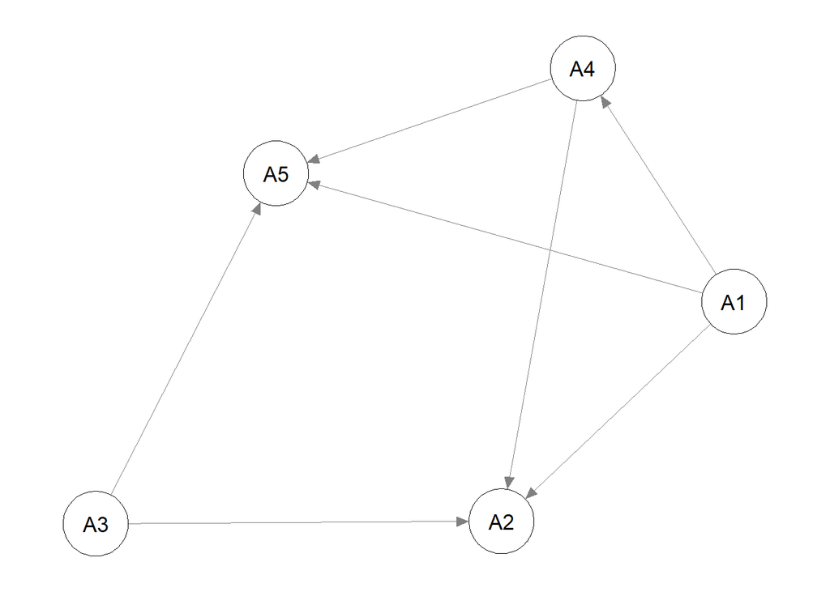

```r
# GRAFO:
qgraph::qgraph(electre$relacion.dominante)
```

Obtenemos las alternativas A1 y A3.

Vamos a reducir el valor de α para intentar sacar mejores conclusiones:

```r
electre_red <- multicriterio.metodoELECTRE_I(datos,
                                      pesos.criterios = p,
                                      nivel.concordancia.minimo.alpha = 0.6,
                                      no.se.compensan = d,
                                      que.alternativas = c(1,3)) # Ponemos las alternativas obtenidas anteriormente
electre_red
```

```
## $datos
##                 Alcance del público objetivo Costo Retorno de inversión (ROI)
## A1                                        85   -30                      150.0
## A3                                        60   -10                      200.0
## pesos.criterios                            3     2                        3.5
## no.se.compensan                          Inf    60                        Inf
##                 Duración de la estrategia Capacidad de segmentación
## A1                                     12                      90.0
## A3                                      6                      85.0
## pesos.criterios                         1                       2.5
## no.se.compensan                       Inf                       Inf
##                 Flexibilidad de ajustes
## A1                                    9
## A3                                    8
## pesos.criterios                       2
## no.se.compensan                     Inf
##
## $alpha
## [1] 0.6
##
## $Imas
## , , Alcance del público objetivo
##
##       A1    A3
## A1 FALSE  TRUE
## A3 FALSE FALSE
##
## , , Costo
##
##       A1    A3
## A1 FALSE FALSE
## A3  TRUE FALSE
##
## , , Retorno de inversión (ROI)
##
##       A1    A3
## A1 FALSE FALSE
## A3  TRUE FALSE
##
## , , Duración de la estrategia
```

[output cut: 107 more lines]

```
## A3 FALSE FALSE
##
## $test.discordancia
##      A1   A3
## A1 TRUE TRUE
## A3 TRUE TRUE
##
## $relacion.dominante
##       A1    A3
## A1 FALSE  TRUE
## A3 FALSE FALSE
##
## $nucleo_aprox
## A1
##  1
```

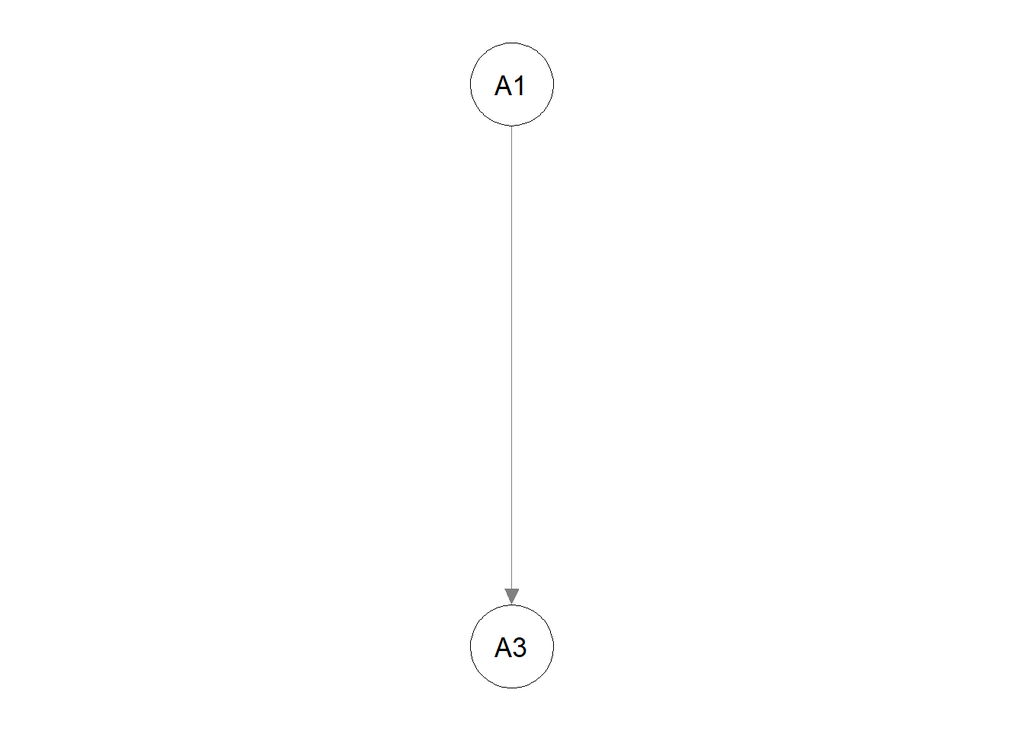

```r
# GRAFO:
qgraph::qgraph(electre_red$relacion.dominante)
```

Nos queda la alternativa A1

**CONCLUSIÓN**: Con el método Electree, obtenemos que la mejor alternativa es A1, es decir, publicidad es las Redes Sociales.

## 3. MÉTODO AHP

Vamos a crear la matriz de comparación entre criterios y las matrices de comparaciones alternativas/criterios:

```r
# MATRIZ DE CRITERIOS
n_criterios <- c("Alcance", "Costo", "ROI", "Duración", "Segmentación", "Flexibilidad")
Xmat_criterios <- multicriterio.crea.matrizvaloraciones_mej(
  c(3, 1/2, 5, 2, 3,
       1/5, 3, 1/2, 1,
            7, 3, 5,
              1/3, 1/2,
                   2),
  6, n_criterios
)
kable(Xmat_criterios, caption = "MATRIZ DE CRITERIOS")
```

MATRIZ DE CRITERIOS

|  | Alcance | Costo | ROI | Duración | Segmentación | Flexibilidad |
| --- | --- | --- | --- | --- | --- | --- |
| Alcance | 1.0000000 | 3.0000000 | 0.5000000 | 5 | 2.0000000 | 3.0 |
| Costo | 0.3333333 | 1.0000000 | 0.2000000 | 3 | 0.5000000 | 1.0 |
| ROI | 2.0000000 | 5.0000000 | 1.0000000 | 7 | 3.0000000 | 5.0 |
| Duración | 0.2000000 | 0.3333333 | 0.1428571 | 1 | 0.3333333 | 0.5 |
| Segmentación | 0.5000000 | 2.0000000 | 0.3333333 | 3 | 1.0000000 | 2.0 |
| Flexibilidad | 0.3333333 | 1.0000000 | 0.2000000 | 2 | 0.5000000 | 1.0 |

```r
# MATRICES DE ALTERNATIVAS/CRITERIOS
n_alternativas <- c("A1", "A2", "A3", "A4", "A5")

# Criterio: Alcance
Xmat_alcance <- multicriterio.crea.matrizvaloraciones_mej(
  c(3, 5, 2, 1/2,
       2, 1/2, 1/5,
          1/3, 1/7,
               1/3),
  5, n_alternativas
)
kable(Xmat_alcance, caption = "ALCANCE")
```

ALCANCE

|  | A1 | A2 | A3 | A4 | A5 |
| --- | --- | --- | --- | --- | --- |
| A1 | 1.0000000 | 3.0 | 5 | 2.0000000 | 0.5000000 |
| A2 | 0.3333333 | 1.0 | 2 | 0.5000000 | 0.2000000 |
| A3 | 0.2000000 | 0.5 | 1 | 0.3333333 | 0.1428571 |
| A4 | 0.5000000 | 2.0 | 3 | 1.0000000 | 0.3333333 |
| A5 | 2.0000000 | 5.0 | 7 | 3.0000000 | 1.0000000 |

```r
# Criterio: Costo
# Se busca minimizar el costo; la alternativa con menor costo es más favorable.
Xmat_costo <- multicriterio.crea.matrizvaloraciones_mej(
  c(1/2, 1/3, 1/2, 2,
         1/2,   2, 3,
                4, 5,
                   3),
  5, n_alternativas
)
kable(Xmat_costo, caption = "COSTO")
```

COSTO

|  | A1 | A2 | A3 | A4 | A5 |
| --- | --- | --- | --- | --- | --- |
| A1 | 1.0 | 0.5000000 | 0.3333333 | 0.5000000 | 2 |
| A2 | 2.0 | 1.0000000 | 0.5000000 | 2.0000000 | 3 |
| A3 | 3.0 | 2.0000000 | 1.0000000 | 4.0000000 | 5 |
| A4 | 2.0 | 0.5000000 | 0.2500000 | 1.0000000 | 3 |
| A5 | 0.5 | 0.3333333 | 0.2000000 | 0.3333333 | 1 |

```r
# Criterio: ROI
# Se maximiza el ROI, así que las alternativas con mayor porcentaje son más favorables.
Xmat_roi <- multicriterio.crea.matrizvaloraciones_mej(
  c(3, 1/2, 2, 5,
       1/5, 1/2, 1/2,
              3, 7,
                 3),
  5, n_alternativas
)
kable(Xmat_roi, caption = "ROI")
```

ROI

|  | A1 | A2 | A3 | A4 | A5 |
| --- | --- | --- | --- | --- | --- |
| A1 | 1.0000000 | 3 | 0.5000000 | 2.0000000 | 5.0 |
| A2 | 0.3333333 | 1 | 0.2000000 | 0.5000000 | 0.5 |
| A3 | 2.0000000 | 5 | 1.0000000 | 3.0000000 | 7.0 |
| A4 | 0.5000000 | 2 | 0.3333333 | 1.0000000 | 3.0 |
| A5 | 0.2000000 | 2 | 0.1428571 | 0.3333333 | 1.0 |

```r
# Criterio: Duración
# Se maximiza la duración; las alternativas con mayor duración son más favorables.
Xmat_duracion <- multicriterio.crea.matrizvaloraciones_mej(
  c(1/2, 2, 3, 2,
         3, 5, 3,
          1/2, 1,
               2),
  5, n_alternativas
)
kable(Xmat_duracion, caption = "DURACIÓN")
```

DURACIÓN

|  | A1 | A2 | A3 | A4 | A5 |
| --- | --- | --- | --- | --- | --- |
| A1 | 1.0000000 | 0.5000000 | 2 | 3.0 | 2 |
| A2 | 2.0000000 | 1.0000000 | 3 | 5.0 | 3 |
| A3 | 0.5000000 | 0.3333333 | 1 | 0.5 | 1 |
| A4 | 0.3333333 | 0.2000000 | 2 | 1.0 | 2 |
| A5 | 0.5000000 | 0.3333333 | 1 | 0.5 | 1 |

```r
# Criterio: Segmentación
# Se maximiza la capacidad de segmentación, así que las alternativas con mayores puntajes son más favorables.
Xmat_segmentacion <- multicriterio.crea.matrizvaloraciones_mej(
  c(3, 2, 2, 5,
      1/2, 1/5, 3,
           1/3, 4,
                7),
  5, n_alternativas
)
kable(Xmat_segmentacion, caption = "SEGMENTACIÓN")
```

SEGMENTACIÓN

|  | A1 | A2 | A3 | A4 | A5 |
| --- | --- | --- | --- | --- | --- |
| A1 | 1.0000000 | 3.0000000 | 2.00 | 2.0000000 | 5 |
| A2 | 0.3333333 | 1.0000000 | 0.50 | 0.2000000 | 3 |
| A3 | 0.5000000 | 2.0000000 | 1.00 | 0.3333333 | 4 |
| A4 | 0.5000000 | 5.0000000 | 3.00 | 1.0000000 | 7 |
| A5 | 0.2000000 | 0.3333333 | 0.25 | 0.1428571 | 1 |

```r
# Criterio: Flexibilidad
# Se maximiza la flexibilidad, así que las alternativas con mayores valores son más favorables.
Xmat_flexibilidad <- multicriterio.crea.matrizvaloraciones_mej(
  c(3, 2, 1, 3,
      1/2, 1/3, 1,
           1/2, 2,
                3),
  5, n_alternativas
)
kable(Xmat_flexibilidad, caption = "FLEXIBILIDAD")
```

FLEXIBILIDAD

|  | A1 | A2 | A3 | A4 | A5 |
| --- | --- | --- | --- | --- | --- |
| A1 | 1.0000000 | 3 | 2.0 | 1.0000000 | 3 |
| A2 | 0.3333333 | 1 | 0.5 | 0.3333333 | 1 |
| A3 | 0.5000000 | 2 | 1.0 | 0.5000000 | 2 |
| A4 | 1.0000000 | 3 | 2.0 | 1.0000000 | 3 |
| A5 | 0.3333333 | 1 | 0.5 | 0.3333333 | 1 |

### 3.1. Con funciones de R

#### **Diagramas de jerarquías:**

Vamos crear el diagrama de jerarquías para nuestra empresa. Este nos permitirá ver la importancia de cada alternativa, ofreciendo una forma sencilla de visualizar e interpretar los resultados.

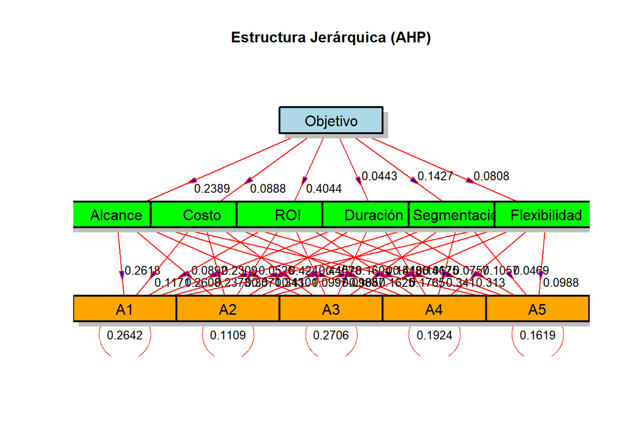

```r
num.alt=5
num.cri=6
Xmatriznivel2 = array(NA,dim=c(num.alt,num.alt,num.cri))
Xmatriznivel2[,,1] = Xmat_alcance
Xmatriznivel2[,,2] = Xmat_costo
Xmatriznivel2[,,3] = Xmat_roi
Xmatriznivel2[,,4] = Xmat_duracion
Xmatriznivel2[,,5] = Xmat_segmentacion
Xmatriznivel2[,,6] = Xmat_flexibilidad
dimnames(Xmatriznivel2)[[1]] = n_alternativas
dimnames(Xmatriznivel2)[[2]] = n_alternativas
dimnames(Xmatriznivel2)[[3]] = n_criterios

multicriterio.metodoahp.diagrama(Xmat_criterios,Xmatriznivel2)
```

#### **Pesos locales:**

##### Pesos locales de los criterios:

```r
pesos.criterios = multicriterio.metodoAHP.variante3.basico(Xmat_criterios)
pesos.criterios
```

```
## $Xmat
##                Alcance     Costo       ROI Duración Segmentación Flexibilidad
## Alcance      1.0000000 3.0000000 0.5000000        5    2.0000000          3.0
## Costo        0.3333333 1.0000000 0.2000000        3    0.5000000          1.0
## ROI          2.0000000 5.0000000 1.0000000        7    3.0000000          5.0
## Duración     0.2000000 0.3333333 0.1428571        1    0.3333333          0.5
## Segmentación 0.5000000 2.0000000 0.3333333        3    1.0000000          2.0
## Flexibilidad 0.3333333 1.0000000 0.2000000        2    0.5000000          1.0
##
## $sumacolumnas
##      Alcance        Costo          ROI     Duración Segmentación Flexibilidad
##     4.366667    12.333333     2.376190    21.000000     7.333333    12.500000
##
## $Xmat.normalizada
##                 Alcance      Costo        ROI   Duración Segmentación
## Alcance      0.22900763 0.24324324 0.21042084 0.23809524   0.27272727
## Costo        0.07633588 0.08108108 0.08416834 0.14285714   0.06818182
## ROI          0.45801527 0.40540541 0.42084168 0.33333333   0.40909091
## Duración     0.04580153 0.02702703 0.06012024 0.04761905   0.04545455
## Segmentación 0.11450382 0.16216216 0.14028056 0.14285714   0.13636364
## Flexibilidad 0.07633588 0.08108108 0.08416834 0.09523810   0.06818182
##              Flexibilidad
## Alcance              0.24
## Costo                0.08
## ROI                  0.40
## Duración             0.04
## Segmentación         0.16
## Flexibilidad         0.08
##
## $valoraciones.ahp
##      Alcance        Costo          ROI     Duración Segmentación Flexibilidad
##   0.23891570   0.08877071   0.40444777   0.04433706   0.14269455   0.08083420
##
## $valoraciones.ahp.ordenadas
##          ROI      Alcance Segmentación        Costo Flexibilidad     Duración
##   0.40444777   0.23891570   0.14269455   0.08877071   0.08083420   0.04433706
##
## $tablaresumen
##                Alcance      Costo       ROI Duración Segmentación Flexibilidad
## Alcance      1.0000000  3.0000000 0.5000000        5    2.0000000          3.0
## Costo        0.3333333  1.0000000 0.2000000        3    0.5000000          1.0
## ROI          2.0000000  5.0000000 1.0000000        7    3.0000000          5.0
## Duración     0.2000000  0.3333333 0.1428571        1    0.3333333          0.5
## Segmentación 0.5000000  2.0000000 0.3333333        3    1.0000000          2.0
## Flexibilidad 0.3333333  1.0000000 0.2000000        2    0.5000000          1.0
##              4.3666667 12.3333333 2.3761905       21    7.3333333         12.5
##                 Alcance      Costo        ROI   Duración Segmentación
## Alcance      0.22900763 0.24324324 0.21042084 0.23809524   0.27272727
## Costo        0.07633588 0.08108108 0.08416834 0.14285714   0.06818182
## ROI          0.45801527 0.40540541 0.42084168 0.33333333   0.40909091
## Duración     0.04580153 0.02702703 0.06012024 0.04761905   0.04545455
## Segmentación 0.11450382 0.16216216 0.14028056 0.14285714   0.13636364
## Flexibilidad 0.07633588 0.08108108 0.08416834 0.09523810   0.06818182
##                      NA         NA         NA         NA           NA
##              Flexibilidad prioridades.relativas
## Alcance              0.24            0.23891570
## Costo                0.08            0.08877071
## ROI                  0.40            0.40444777
## Duración             0.04            0.04433706
## Segmentación         0.16            0.14269455
## Flexibilidad         0.08            0.08083420
##                        NA                    NA
```

El criterio con mayor importancia es el ROI, con un peso de 0.4044, destacándose por encima de los demás criterios. En cambio, Duración es la menos relevante, con un peso de 0.0443, ya que tiene un impacto mínimo en la decisión final. Costo (0.0887), Alcance (0.2389), Flexibilidad (0.0808) y Segmentación (0.1426) tienen una importancia intermedia, con valores similares entre ellos, aunque el ROI y el Alcance sobresalen ligeramente.

##### Pesos locales de las alternativas en función de cada criterio:

###### Alcance:

```r
pesos.alcance= multicriterio.metodoAHP.variante3.basico(Xmat_alcance)
pesos.alcance
```

```
## $Xmat
##           A1  A2 A3        A4        A5
## A1 1.0000000 3.0  5 2.0000000 0.5000000
## A2 0.3333333 1.0  2 0.5000000 0.2000000
## A3 0.2000000 0.5  1 0.3333333 0.1428571
## A4 0.5000000 2.0  3 1.0000000 0.3333333
## A5 2.0000000 5.0  7 3.0000000 1.0000000
##
## $sumacolumnas
##        A1        A2        A3        A4        A5
##  4.033333 11.500000 18.000000  6.833333  2.176190
##
## $Xmat.normalizada
##            A1         A2         A3         A4         A5
## A1 0.24793388 0.26086957 0.27777778 0.29268293 0.22975930
## A2 0.08264463 0.08695652 0.11111111 0.07317073 0.09190372
## A3 0.04958678 0.04347826 0.05555556 0.04878049 0.06564551
## A4 0.12396694 0.17391304 0.16666667 0.14634146 0.15317287
## A5 0.49586777 0.43478261 0.38888889 0.43902439 0.45951860
##
## $valoraciones.ahp
##         A1         A2         A3         A4         A5
## 0.26180469 0.08915734 0.05260932 0.15281220 0.44361645
##
## $valoraciones.ahp.ordenadas
##         A5         A1         A4         A2         A3
## 0.44361645 0.26180469 0.15281220 0.08915734 0.05260932
##
## $tablaresumen
##           A1   A2 A3        A4        A5         A1         A2         A3
## A1 1.0000000  3.0  5 2.0000000 0.5000000 0.24793388 0.26086957 0.27777778
## A2 0.3333333  1.0  2 0.5000000 0.2000000 0.08264463 0.08695652 0.11111111
## A3 0.2000000  0.5  1 0.3333333 0.1428571 0.04958678 0.04347826 0.05555556
## A4 0.5000000  2.0  3 1.0000000 0.3333333 0.12396694 0.17391304 0.16666667
## A5 2.0000000  5.0  7 3.0000000 1.0000000 0.49586777 0.43478261 0.38888889
##    4.0333333 11.5 18 6.8333333 2.1761905         NA         NA         NA
##            A4         A5 prioridades.relativas
## A1 0.29268293 0.22975930            0.26180469
## A2 0.07317073 0.09190372            0.08915734
## A3 0.04878049 0.06564551            0.05260932
## A4 0.14634146 0.15317287            0.15281220
## A5 0.43902439 0.45951860            0.44361645
##            NA         NA                    NA
```

Si solo consideramos el Alcance como criterio para la elección de la mejor alternativa, los resultados obtenidos para la elección de la mejor alternativa son: A5(0.4436) > A1(0.2618) > A4(0.1528) > A2(0.0891) > A3(0.0526).

###### Costo:

```r
pesos.costo= multicriterio.metodoAHP.variante3.basico(Xmat_costo)
pesos.costo
```

```
## $Xmat
##     A1        A2        A3        A4 A5
## A1 1.0 0.5000000 0.3333333 0.5000000  2
## A2 2.0 1.0000000 0.5000000 2.0000000  3
## A3 3.0 2.0000000 1.0000000 4.0000000  5
## A4 2.0 0.5000000 0.2500000 1.0000000  3
## A5 0.5 0.3333333 0.2000000 0.3333333  1
##
## $sumacolumnas
##        A1        A2        A3        A4        A5
##  8.500000  4.333333  2.283333  7.833333 14.000000
##
## $Xmat.normalizada
##            A1         A2         A3         A4         A5
## A1 0.11764706 0.11538462 0.14598540 0.06382979 0.14285714
## A2 0.23529412 0.23076923 0.21897810 0.25531915 0.21428571
## A3 0.35294118 0.46153846 0.43795620 0.51063830 0.35714286
## A4 0.23529412 0.11538462 0.10948905 0.12765957 0.21428571
## A5 0.05882353 0.07692308 0.08759124 0.04255319 0.07142857
##
## $valoraciones.ahp
##         A1         A2         A3         A4         A5
## 0.11714080 0.23092926 0.42404340 0.16042261 0.06746392
##
## $valoraciones.ahp.ordenadas
##         A3         A2         A4         A1         A5
## 0.42404340 0.23092926 0.16042261 0.11714080 0.06746392
##
## $tablaresumen
##     A1        A2        A3        A4 A5         A1         A2         A3
## A1 1.0 0.5000000 0.3333333 0.5000000  2 0.11764706 0.11538462 0.14598540
## A2 2.0 1.0000000 0.5000000 2.0000000  3 0.23529412 0.23076923 0.21897810
## A3 3.0 2.0000000 1.0000000 4.0000000  5 0.35294118 0.46153846 0.43795620
## A4 2.0 0.5000000 0.2500000 1.0000000  3 0.23529412 0.11538462 0.10948905
## A5 0.5 0.3333333 0.2000000 0.3333333  1 0.05882353 0.07692308 0.08759124
##    8.5 4.3333333 2.2833333 7.8333333 14         NA         NA         NA
##            A4         A5 prioridades.relativas
## A1 0.06382979 0.14285714            0.11714080
## A2 0.25531915 0.21428571            0.23092926
## A3 0.51063830 0.35714286            0.42404340
## A4 0.12765957 0.21428571            0.16042261
## A5 0.04255319 0.07142857            0.06746392
##            NA         NA                    NA
```

Si solo consideramos el Costo como criterio para la elección de la mejor alternativa, los resultados obtenidos para la elección de la mejor alternativa son: A3(0.4240) > A2(0.2309) > A4(0.1604) > A1(0.1171) > A5(0.0674).

###### ROI:

```r
pesos.ROI= multicriterio.metodoAHP.variante3.basico(Xmat_roi)
pesos.ROI
```

```
## $Xmat
##           A1 A2        A3        A4  A5
## A1 1.0000000  3 0.5000000 2.0000000 5.0
## A2 0.3333333  1 0.2000000 0.5000000 0.5
## A3 2.0000000  5 1.0000000 3.0000000 7.0
## A4 0.5000000  2 0.3333333 1.0000000 3.0
## A5 0.2000000  2 0.1428571 0.3333333 1.0
##
## $sumacolumnas
##        A1        A2        A3        A4        A5
##  4.033333 13.000000  2.176190  6.833333 16.500000
##
## $Xmat.normalizada
##            A1         A2         A3         A4         A5
## A1 0.24793388 0.23076923 0.22975930 0.29268293 0.30303030
## A2 0.08264463 0.07692308 0.09190372 0.07317073 0.03030303
## A3 0.49586777 0.38461538 0.45951860 0.43902439 0.42424242
## A4 0.12396694 0.15384615 0.15317287 0.14634146 0.18181818
## A5 0.04958678 0.15384615 0.06564551 0.04878049 0.06060606
##
## $valoraciones.ahp
##         A1         A2         A3         A4         A5
## 0.26083513 0.07098904 0.44065371 0.15182912 0.07569300
##
## $valoraciones.ahp.ordenadas
##         A3         A1         A4         A5         A2
## 0.44065371 0.26083513 0.15182912 0.07569300 0.07098904
##
## $tablaresumen
##           A1 A2        A3        A4   A5         A1         A2         A3
## A1 1.0000000  3 0.5000000 2.0000000  5.0 0.24793388 0.23076923 0.22975930
## A2 0.3333333  1 0.2000000 0.5000000  0.5 0.08264463 0.07692308 0.09190372
## A3 2.0000000  5 1.0000000 3.0000000  7.0 0.49586777 0.38461538 0.45951860
## A4 0.5000000  2 0.3333333 1.0000000  3.0 0.12396694 0.15384615 0.15317287
## A5 0.2000000  2 0.1428571 0.3333333  1.0 0.04958678 0.15384615 0.06564551
##    4.0333333 13 2.1761905 6.8333333 16.5         NA         NA         NA
##            A4         A5 prioridades.relativas
## A1 0.29268293 0.30303030            0.26083513
## A2 0.07317073 0.03030303            0.07098904
## A3 0.43902439 0.42424242            0.44065371
## A4 0.14634146 0.18181818            0.15182912
## A5 0.04878049 0.06060606            0.07569300
##            NA         NA                    NA
```

Si solo consideramos el ROI como criterio para la elección de la mejor alternativa, los resultados obtenidos para la elección de la mejor alternativa son: A3(0.4406) > A1(0.2608) > A4(0.1518) > A5(0.0756) > A2(0.0709).

###### Duración:

```r
pesos.duracion= multicriterio.metodoAHP.variante3.basico(Xmat_duracion)
pesos.duracion
```

```
## $Xmat
##           A1        A2 A3  A4 A5
## A1 1.0000000 0.5000000  2 3.0  2
## A2 2.0000000 1.0000000  3 5.0  3
## A3 0.5000000 0.3333333  1 0.5  1
## A4 0.3333333 0.2000000  2 1.0  2
## A5 0.5000000 0.3333333  1 0.5  1
##
## $sumacolumnas
##        A1        A2        A3        A4        A5
##  4.333333  2.366667  9.000000 10.000000  9.000000
##
## $Xmat.normalizada
##            A1         A2        A3   A4        A5
## A1 0.23076923 0.21126761 0.2222222 0.30 0.2222222
## A2 0.46153846 0.42253521 0.3333333 0.50 0.3333333
## A3 0.11538462 0.14084507 0.1111111 0.05 0.1111111
## A4 0.07692308 0.08450704 0.2222222 0.10 0.2222222
## A5 0.11538462 0.14084507 0.1111111 0.05 0.1111111
##
## $valoraciones.ahp
##        A1        A2        A3        A4        A5
## 0.2372963 0.4101481 0.1056904 0.1411749 0.1056904
##
## $valoraciones.ahp.ordenadas
##        A2        A1        A4        A3        A5
## 0.4101481 0.2372963 0.1411749 0.1056904 0.1056904
##
## $tablaresumen
##           A1        A2 A3   A4 A5         A1         A2        A3   A4
## A1 1.0000000 0.5000000  2  3.0  2 0.23076923 0.21126761 0.2222222 0.30
## A2 2.0000000 1.0000000  3  5.0  3 0.46153846 0.42253521 0.3333333 0.50
## A3 0.5000000 0.3333333  1  0.5  1 0.11538462 0.14084507 0.1111111 0.05
## A4 0.3333333 0.2000000  2  1.0  2 0.07692308 0.08450704 0.2222222 0.10
## A5 0.5000000 0.3333333  1  0.5  1 0.11538462 0.14084507 0.1111111 0.05
##    4.3333333 2.3666667  9 10.0  9         NA         NA        NA   NA
##           A5 prioridades.relativas
## A1 0.2222222             0.2372963
## A2 0.3333333             0.4101481
## A3 0.1111111             0.1056904
## A4 0.2222222             0.1411749
## A5 0.1111111             0.1056904
##           NA                    NA
```

Si solo consideramos la Duración como criterio para la elección de la mejor alternativa, los resultados obtenidos para la elección de la mejor alternativa son: A2(0.4101) > A1(0.2372) > A4(0.1411) > A3(0.1056) = A5(0.1056).

###### Segmentación:

```r
pesos.segmentacion= multicriterio.metodoAHP.variante3.basico(Xmat_segmentacion)
pesos.segmentacion
```

```
## $Xmat
##           A1        A2   A3        A4 A5
## A1 1.0000000 3.0000000 2.00 2.0000000  5
## A2 0.3333333 1.0000000 0.50 0.2000000  3
## A3 0.5000000 2.0000000 1.00 0.3333333  4
## A4 0.5000000 5.0000000 3.00 1.0000000  7
## A5 0.2000000 0.3333333 0.25 0.1428571  1
##
## $sumacolumnas
##        A1        A2        A3        A4        A5
##  2.533333 11.333333  6.750000  3.676190 20.000000
##
## $Xmat.normalizada
##            A1         A2         A3         A4   A5
## A1 0.39473684 0.26470588 0.29629630 0.54404145 0.25
## A2 0.13157895 0.08823529 0.07407407 0.05440415 0.15
## A3 0.19736842 0.17647059 0.14814815 0.09067358 0.20
## A4 0.19736842 0.44117647 0.44444444 0.27202073 0.35
## A5 0.07894737 0.02941176 0.03703704 0.03886010 0.05
##
## $valoraciones.ahp
##         A1         A2         A3         A4         A5
## 0.34995609 0.09965849 0.16253215 0.34100201 0.04685125
##
## $valoraciones.ahp.ordenadas
##         A1         A4         A3         A2         A5
## 0.34995609 0.34100201 0.16253215 0.09965849 0.04685125
##
## $tablaresumen
##           A1         A2   A3        A4 A5         A1         A2         A3
## A1 1.0000000  3.0000000 2.00 2.0000000  5 0.39473684 0.26470588 0.29629630
## A2 0.3333333  1.0000000 0.50 0.2000000  3 0.13157895 0.08823529 0.07407407
## A3 0.5000000  2.0000000 1.00 0.3333333  4 0.19736842 0.17647059 0.14814815
## A4 0.5000000  5.0000000 3.00 1.0000000  7 0.19736842 0.44117647 0.44444444
## A5 0.2000000  0.3333333 0.25 0.1428571  1 0.07894737 0.02941176 0.03703704
##    2.5333333 11.3333333 6.75 3.6761905 20         NA         NA         NA
##            A4   A5 prioridades.relativas
## A1 0.54404145 0.25            0.34995609
## A2 0.05440415 0.15            0.09965849
## A3 0.09067358 0.20            0.16253215
## A4 0.27202073 0.35            0.34100201
## A5 0.03886010 0.05            0.04685125
##            NA   NA                    NA
```

Si solo consideramos la Segmentación como criterio para la elección de la mejor alternativa, los resultados obtenidos para la elección de la mejor alternativa son: A1(0.3499) > A4(0.3410) > A3(0.1625) > A2(0.0996) > A5(0.0468).

###### Flexibilidad:

```r
pesos.flexibilidad= multicriterio.metodoAHP.variante3.basico(Xmat_flexibilidad)
pesos.flexibilidad
```

```
## $Xmat
##           A1 A2  A3        A4 A5
## A1 1.0000000  3 2.0 1.0000000  3
## A2 0.3333333  1 0.5 0.3333333  1
## A3 0.5000000  2 1.0 0.5000000  2
## A4 1.0000000  3 2.0 1.0000000  3
## A5 0.3333333  1 0.5 0.3333333  1
##
## $sumacolumnas
##        A1        A2        A3        A4        A5
##  3.166667 10.000000  6.000000  3.166667 10.000000
##
## $Xmat.normalizada
##           A1  A2         A3        A4  A5
## A1 0.3157895 0.3 0.33333333 0.3157895 0.3
## A2 0.1052632 0.1 0.08333333 0.1052632 0.1
## A3 0.1578947 0.2 0.16666667 0.1578947 0.2
## A4 0.3157895 0.3 0.33333333 0.3157895 0.3
## A5 0.1052632 0.1 0.08333333 0.1052632 0.1
##
## $valoraciones.ahp
##         A1         A2         A3         A4         A5
## 0.31298246 0.09877193 0.17649123 0.31298246 0.09877193
##
## $valoraciones.ahp.ordenadas
##         A1         A4         A3         A2         A5
## 0.31298246 0.31298246 0.17649123 0.09877193 0.09877193
##
## $tablaresumen
##           A1 A2  A3        A4 A5        A1  A2         A3        A4  A5
## A1 1.0000000  3 2.0 1.0000000  3 0.3157895 0.3 0.33333333 0.3157895 0.3
## A2 0.3333333  1 0.5 0.3333333  1 0.1052632 0.1 0.08333333 0.1052632 0.1
## A3 0.5000000  2 1.0 0.5000000  2 0.1578947 0.2 0.16666667 0.1578947 0.2
## A4 1.0000000  3 2.0 1.0000000  3 0.3157895 0.3 0.33333333 0.3157895 0.3
## A5 0.3333333  1 0.5 0.3333333  1 0.1052632 0.1 0.08333333 0.1052632 0.1
##    3.1666667 10 6.0 3.1666667 10        NA  NA         NA        NA  NA
##    prioridades.relativas
## A1            0.31298246
## A2            0.09877193
## A3            0.17649123
## A4            0.31298246
## A5            0.09877193
##                       NA
```

Si solo consideramos la Flexibilidad como criterio para la elección de la mejor alternativa, los resultados obtenidos para la elección de la mejor alternativa son: A1(0.3129) = A4(0.3129) > A3(0.1764) > A2(0.0987) = A5(0.0987).

#### **Consistencia:**

##### Consistencia de los criterios:

```r
multicriterio.metodoAHP.coef.inconsistencia(Xmat_criterios)
```

```
## $lambda
## [1] 6.068033
##
## $m
## [1] 6
##
## $CI.coef.inconsistencia
## [1] 0.01360652
##
## $CA.aleatorio
## [1] 1.24
##
## $RI.coef.inconsistencia
## [1] 0.010973
##
## $mensaje
## [1] "Consistencia aceptable"
```

La consistencia de la matriz de comparación de criterios es aceptable, cumpliendo con los parámetros establecidos. Por tanto, las preferencias expresadas en dicha matriz son razonablemente consistentes y pueden considerarse válidas para el análisis de decisiones.

##### Consistencia por criterios:

###### Alcance:

```r
multicriterio.metodoAHP.coef.inconsistencia(Xmat_alcance)
```

```
## $lambda
## [1] 5.028022
##
## $m
## [1] 5
##
## $CI.coef.inconsistencia
## [1] 0.007005579
##
## $CA.aleatorio
## [1] 1.12
##
## $RI.coef.inconsistencia
## [1] 0.006254981
##
## $mensaje
## [1] "Consistencia aceptable"
```

La consistencia del Alcance es aceptable.

###### Costo:

```r
multicriterio.metodoAHP.coef.inconsistencia(Xmat_costo)
```

```
## $lambda
## [1] 5.121735
##
## $m
## [1] 5
##
## $CI.coef.inconsistencia
## [1] 0.03043382
##
## $CA.aleatorio
## [1] 1.12
##
## $RI.coef.inconsistencia
## [1] 0.02717305
##
## $mensaje
## [1] "Consistencia aceptable"
```

La consistencia del Costo es aceptable.

###### ROI:

```r
multicriterio.metodoAHP.coef.inconsistencia(Xmat_roi)
```

```
## $lambda
## [1] 5.173045
##
## $m
## [1] 5
##
## $CI.coef.inconsistencia
## [1] 0.0432612
##
## $CA.aleatorio
## [1] 1.12
##
## $RI.coef.inconsistencia
## [1] 0.03862607
##
## $mensaje
## [1] "Consistencia aceptable"
```

La consistencia del ROI es aceptable.

###### Duración:

```r
multicriterio.metodoAHP.coef.inconsistencia(Xmat_duracion)
```

```
## $lambda
## [1] 5.22569
##
## $m
## [1] 5
##
## $CI.coef.inconsistencia
## [1] 0.05642246
##
## $CA.aleatorio
## [1] 1.12
##
## $RI.coef.inconsistencia
## [1] 0.0503772
##
## $mensaje
## [1] "Consistencia aceptable"
```

La consistencia de la Duración es aceptable.

###### Segmentación:

```r
multicriterio.metodoAHP.coef.inconsistencia(Xmat_segmentacion)
```

```
## $lambda
## [1] 5.224009
##
## $m
## [1] 5
##
## $CI.coef.inconsistencia
## [1] 0.05600213
##
## $CA.aleatorio
## [1] 1.12
##
## $RI.coef.inconsistencia
## [1] 0.0500019
##
## $mensaje
## [1] "Consistencia aceptable"
```

La consistencia de la segmentación es aceptable.

###### Flexibilidad:

```r
multicriterio.metodoAHP.coef.inconsistencia(Xmat_flexibilidad)
```

```
## $lambda
## [1] 5.013263
##
## $m
## [1] 5
##
## $CI.coef.inconsistencia
## [1] 0.00331572
##
## $CA.aleatorio
## [1] 1.12
##
## $RI.coef.inconsistencia
## [1] 0.002960464
##
## $mensaje
## [1] "Consistencia aceptable"
```

La consistencia de la flexibilidad es aceptable.

#### **Pesos globales:**

```r
tabla.pesosglobales.ahp =
multicriterio.metodoAHP.pesosglobales_entabla(
    pesos.criterios$valoraciones.ahp,
    rbind(pesos.alcance$valoraciones.ahp,
          pesos.costo$valoraciones.ahp,
          pesos.ROI$valoraciones.ahp,
          pesos.duracion$valoraciones.ahp,
          pesos.segmentacion$valoraciones.ahp,
          pesos.flexibilidad$valoraciones.ahp))
knitr::kable(tabla.pesosglobales.ahp)
```

|  | Alcance | Costo | ROI | Duración | Segmentación | Flexibilidad | Ponderadores Globales |
| --- | --- | --- | --- | --- | --- | --- | --- |
| A1 | 0.2618047 | 0.1171408 | 0.2608351 | 0.2372963 | 0.3499561 | 0.3129825 | 0.2641996 |
| A2 | 0.0891573 | 0.2309293 | 0.0709890 | 0.4101481 | 0.0996585 | 0.0987719 | 0.1109018 |
| A3 | 0.0526093 | 0.4240434 | 0.4406537 | 0.1056904 | 0.1625321 | 0.1764912 | 0.2705782 |
| A4 | 0.1528122 | 0.1604226 | 0.1518291 | 0.1411749 | 0.3410020 | 0.3129825 | 0.1923751 |
| A5 | 0.4436165 | 0.0674639 | 0.0756930 | 0.1056904 | 0.0468513 | 0.0987719 | 0.1619452 |
| Ponder.Criterios | 0.2389157 | 0.0887707 | 0.4044478 | 0.0443371 | 0.1426946 | 0.0808342 | NA |

```r
# En porcentajes:
knitr::kable(tabla.pesosglobales.ahp*100,digits = 2)
```

|  | Alcance | Costo | ROI | Duración | Segmentación | Flexibilidad | Ponderadores Globales |
| --- | --- | --- | --- | --- | --- | --- | --- |
| A1 | 26.18 | 11.71 | 26.08 | 23.73 | 35.00 | 31.30 | 26.42 |
| A2 | 8.92 | 23.09 | 7.10 | 41.01 | 9.97 | 9.88 | 11.09 |
| A3 | 5.26 | 42.40 | 44.07 | 10.57 | 16.25 | 17.65 | 27.06 |
| A4 | 15.28 | 16.04 | 15.18 | 14.12 | 34.10 | 31.30 | 19.24 |
| A5 | 44.36 | 6.75 | 7.57 | 10.57 | 4.69 | 9.88 | 16.19 |
| Ponder.Criterios | 23.89 | 8.88 | 40.44 | 4.43 | 14.27 | 8.08 | NA |

Hablando en porcentajes, la alternativa con mayor ponderador global es A3 (27.06), es decir, Email Marketing. En consecuencia, podemos considerar esta alternativa como la más preferida en función de los criterios que hemos considerado. En segundo lugar se encuentra la alternativa 1 (26.42), en tercer lugar la alternativa 4 (19.24) y en cuarto lugar la alternativa 5 (16.19). En último lugar se encuentra A2 (11.09), es decir, Marketing de Contenidos. En consecuencia, podemos decir que esta alternativa es la menos preferida en función de los criterios que hemos considerado.

### 3.2 Librería AHP

```r
library(ahp)

# ahp::RunGUI()
datosAHP = ahp::Load("datosAHP.ahp")
datosAHP
```

```
##                                       levelName
## 1  Seleccion de Estrategia de Marketing Digital
## 2   ¦--Alcance
## 3   ¦   ¦--A1
## 4   ¦   ¦--A2
## 5   ¦   ¦--A3
## 6   ¦   ¦--A4
## 7   ¦   °--A5
## 8   ¦--Costo
## 9   ¦   ¦--A1
## 10  ¦   ¦--A2
## 11  ¦   ¦--A3
## 12  ¦   ¦--A4
## 13  ¦   °--A5
## 14  ¦--ROI
```

[output cut: 23 more lines]

#### **Diagramas de jerarquías:**

```r
Calculate(datosAHP)
# Visualize(datosAHP)

Visualize_mej = function(modeloahp) {
  sink("temp.txt")
  s1 = Visualize(modeloahp)
  sink()
  unlink("temp.txt")
  s1
}
Visualize_mej(datosAHP)
```

[interactive chart not shown]

#### **Prioridades:**

```r
print(datosAHP, priority= function(x)x$parent$priority["Total", x$name])
```

```
##                                       levelName   priority
## 1  Seleccion de Estrategia de Marketing Digital         NA
## 2   ¦--Alcance                                  0.23934142
## 3   ¦   ¦--A1                                   0.26192318
## 4   ¦   ¦--A2                                   0.08867844
## 5   ¦   ¦--A3                                   0.05239084
## 6   ¦   ¦--A4                                   0.15235940
## 7   ¦   °--A5                                   0.44464814
## 8   ¦--Costo                                    0.08775301
## 9   ¦   ¦--A1                                   0.11419908
## 10  ¦   ¦--A2                                   0.23231195
## 11  ¦   ¦--A3                                   0.42939338
## 12  ¦   ¦--A4                                   0.15785328
## 13  ¦   °--A5                                   0.06624232
## 14  ¦--ROI                                      0.40568795
```

[output cut: 23 more lines]

```r
# Analizar
Analyze(datosAHP,variable="priority" ,sort ="orig")
```

```
##                                                Priority    A1    A2    A3    A4
## 1 Seleccion de Estrategia de Marketing Digital   100.0%    NA    NA    NA    NA
## 2  ¦--Alcance                                     23.9% 26.2%  8.9%  5.2% 15.2%
## 3  ¦--Costo                                        8.8% 11.4% 23.2% 42.9% 15.8%
## 4  ¦--ROI                                         40.6% 26.3%  6.9% 44.2% 15.3%
## 5  ¦--Duracion                                     4.4% 24.2% 41.9% 10.2% 13.5%
## 6  ¦--Segmentacion                                14.3% 35.9%  9.5% 15.8% 34.3%
## 7  °--Flexibilidad                                 8.1% 31.3%  9.9% 17.6% 31.3%
##      A5 Inconsistency
## 1    NA          1.1%
## 2 44.5%          0.6%
## 3  6.6%          2.7%
## 4  7.3%          3.9%
## 5 10.2%          5.1%
## 6  4.5%          5.1%
## 7  9.9%          0.3%
```

```r
# Analizar con Tabla Mejorada
aa = AnalyzeTable(datosAHP)
formattable::as.htmlwidget(aa)
```

|  | Weight | A3 | A1 | A4 | A5 | A2 | Inconsistency |
| --- | --- | --- | --- | --- | --- | --- | --- |
| Seleccion de Estrategia de Marketing Digital | 100.0% | 27.1% | 26.7% | 19.2% | 16.1% | 11.0% | 1.1% |
| ROI | 40.6% | 17.9% | 10.7% | 6.2% | 3.0% | 2.8% | 3.9% |
| Alcance | 23.9% | 1.3% | 6.3% | 3.6% | 10.6% | 2.1% | 0.6% |
| Segmentacion | 14.3% | 2.3% | 5.1% | 4.9% | 0.6% | 1.4% | 5.1% |
| Costo | 8.8% | 3.8% | 1.0% | 1.4% | 0.6% | 2.0% | 2.7% |
| Flexibilidad | 8.1% | 1.4% | 2.5% | 2.5% | 0.8% | 0.8% | 0.3% |
| Duracion | 4.4% | 0.4% | 1.1% | 0.6% | 0.4% | 1.8% | 5.1% |

```r
aab = AnalyzeTable(datosAHP,variable = "priority")
formattable::as.htmlwidget(aab)
```

|  | Priority | A3 | A1 | A4 | A5 | A2 | Inconsistency |
| --- | --- | --- | --- | --- | --- | --- | --- |
| Seleccion de Estrategia de Marketing Digital | 100.0% |  |  |  |  |  | 1.1% |
| ROI | 40.6% | 44.2% | 26.3% | 15.3% | 7.3% | 6.9% | 3.9% |
| Alcance | 23.9% | 5.2% | 26.2% | 15.2% | 44.5% | 8.9% | 0.6% |
| Segmentacion | 14.3% | 15.8% | 35.9% | 34.3% | 4.5% | 9.5% | 5.1% |
| Costo | 8.8% | 42.9% | 11.4% | 15.8% | 6.6% | 23.2% | 2.7% |
| Flexibilidad | 8.1% | 17.6% | 31.3% | 31.3% | 9.9% | 9.9% | 0.3% |
| Duracion | 4.4% | 10.2% | 24.2% | 13.5% | 10.2% | 41.9% | 5.1% |

## CONCLUSIÓN FINAL

En comparación con las otras alternativas, A1 sobresale en los aspectos más cruciales del marketing digital, como la eficacia en la captación de clientes y la capacidad de adaptación, lo que justifica su elección como la mejor opción. Por lo tanto, se recomienda que Tech Solutions implemente la Publicidad en Redes Sociales como la principal estrategia de marketing digital para el próximo año, con el objetivo de maximizar su visibilidad y fortalecer su presencia en el mercado.